# PH700 - Lab 1

Gabriel Carrasco Escobar

February 20 2019

### Q1. Distribution of bw across insurance

#### Compare the health outcome “bw” distribution between women that are covered by health insurance and those who are not (variable “insurance” = 1 if yes). Justify your approach (max 3 sentences)

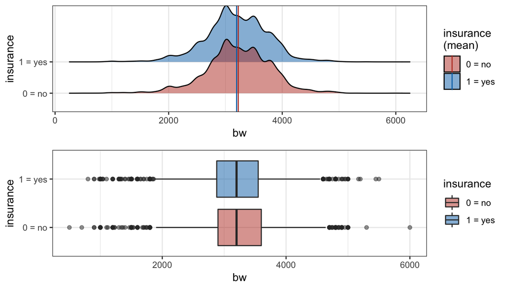

```r
s1<-dat %>% filter(insurance!="") %>%
  summaryBy(bw~insurance, data=., FUN=c(length, mean, sd, median, min, max))
p1<-dat %>% filter(insurance!="") %>%
  ggplot(aes(y=insurance, x=bw, fill=insurance)) +
  geom_density_ridges(alpha = .5) +
  geom_vline(data = s1, aes(xintercept = bw.mean, col=insurance)) +
  scale_fill_nejm() + scale_color_nejm() +
  labs(color="insurance \n(mean)", fill="insurance \n(mean)") +
  theme_bw()
p2<-dat %>% filter(insurance!="") %>%
  ggplot(aes(x=insurance, y=bw, fill=insurance)) +
  geom_boxplot(alpha = .5) +
  scale_fill_nejm() +
  coord_flip() +
  theme_bw()

fig<-grid.arrange(p1,p2, nrow = 2)
```

```r
s1
```

```
##   insurance bw.length  bw.mean    bw.sd bw.median bw.min bw.max
## 1    0 = no      4660 3225.674 572.8367      3200    500   6000
## 2   1 = yes      6222 3196.742 552.6014      3200    800   5500
```

There are slight differences in the birthweight at birth of children from women that are covered by health insurance and those who are not.

### Q2. Linear regresssion

#### Use a linear regression model to describe the same insurance-related inequality in “bw”.

```r
lm1<-dat %>% filter(insurance!="") %>%
  lm(bw~insurance,data=.)
summary(lm1)
```

```
##
## Call:
## lm(formula = bw ~ insurance, data = .)
##
## Residuals:
##      Min       1Q   Median       3Q      Max
## -2725.67  -325.67     3.26   374.33  2774.33
##
## Coefficients:
##                  Estimate Std. Error t value Pr(>|t|)
## (Intercept)      3225.674      8.223  392.26  < 2e-16 ***
## insurance1 = yes  -28.933     10.875   -2.66  0.00782 **
## ---
## Signif. codes:  0 '***' 0.001 '**' 0.01 '*' 0.05 '.' 0.1 ' ' 1
##
## Residual standard error: 561.4 on 10880 degrees of freedom
## Multiple R-squared:  0.0006501,  Adjusted R-squared:  0.0005583
## F-statistic: 7.078 on 1 and 10880 DF,  p-value: 0.007815
```

The birthweight at birth of children from women that are covered by health insurance is in avergae 28.9 grams less in comparison to children from women with no coverage.

### Q3. Adjust for covariates??

#### Would you use additional variables (like age at first marriage, literacy) in this model? Justify your response (max 3 sentences)

No because we’re not explaining the causal mechanism of insurance over bw. We’re trying to reflect the real world

### Q4. Concentration Index - step 1

#### Now consider the variable “wealth_ind” with 5 possible values (1 = poorest). Calculate the proportion of women in each wealth quantile.

```r
(a<-dat %>% group_by(wealth_ind) %>%
  summarise(woman=n(), prop_w=woman/nrow(dat)))
```

```
## # A tibble: 5 x 3
##   wealth_ind  woman prop_w
##   <fct>       <int>  <dbl>
## 1 1 = poorest  3009  0.210
## 2 2 = poorer   3804  0.265
## 3 3 = middle   3497  0.244
## 4 4 = richer   2480  0.173
## 5 5 = richest  1539  0.107
```

There are less proportion of women in the richest wealth quantiles

### Q5. Concentration Index - step 2

#### What is the proportion of women with access to safe drinking water (safe_water=1) in each wealth index group

```r
(b<-dat %>% group_by(wealth_ind) %>%
    summarise(woman=n(), prop_w=woman/nrow(dat), cases=sum(safe_water), prop_cases=cases/woman))
```

```
## # A tibble: 5 x 5
##   wealth_ind  woman prop_w cases prop_cases
##   <fct>       <int>  <dbl> <int>      <dbl>
## 1 1 = poorest  3009  0.210   853      0.283
## 2 2 = poorer   3804  0.265  1904      0.501
## 3 3 = middle   3497  0.244  2165      0.619
## 4 4 = richer   2480  0.173  1917      0.773
## 5 5 = richest  1539  0.107  1325      0.861
```

Women in poorest wealth quantiles have less access to safe drinking water

### Q6. Concentration Index - step 3

#### Calculate (by hand) the Concentration Index to represent the inequality in “safe_water” across wealth index groups.

```r
(c_index<-dat %>% group_by(wealth_ind) %>%
  summarise(woman=n(), prop_w=woman/nrow(dat), cases=sum(safe_water), prop_cases=cases/woman) %>%
  mutate(cum_w=cumsum(woman), pt=cum_w/sum(woman), cum_c=cumsum(cases), Lt=cum_c/sum(cases),
         con_i = (pt*lead(Lt, default=0))-(lead(pt, default=0)*Lt)))
```

```
## # A tibble: 5 x 10
##   wealth_ind  woman prop_w cases prop_cases cum_w    pt cum_c    Lt  con_i
##   <fct>       <int>  <dbl> <int>      <dbl> <int> <dbl> <int> <dbl>  <dbl>
## 1 1 = poorest  3009  0.210   853      0.283  3009 0.210   853 0.104 0.0212
## 2 2 = poorer   3804  0.265  1904      0.501  6813 0.475  2757 0.338 0.0437
## 3 3 = middle   3497  0.244  2165      0.619 10310 0.720  4922 0.603 0.0646
## 4 4 = richer   2480  0.173  1917      0.773 12790 0.893  6839 0.838 0.0549
## 5 5 = richest  1539  0.107  1325      0.861 14329 1      8164 1     0
```

```r
sum(c_index$con_i)
```

```
## [1] 0.1844086
```

The inequality (Concentration Index) in access to safe drinking water across wealth index groups in Peru is 0.18

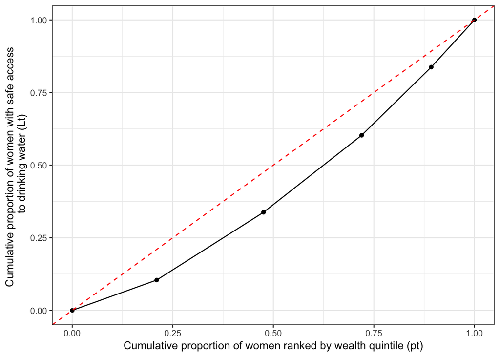

```r
c_index %>% rbind(0) %>% # to include the initial point (origin to zero)
  ggplot(aes(x=pt, y=Lt)) +
  geom_point() +
  geom_line() +
  geom_abline(intercept = 0, slope = 1, col="red", linetype = "dashed") +
  labs(x="Cumulative proportion of women ranked by wealth quintile (pt)",
       y="Cumulative proportion of women with safe access \n to drinking water (Lt)") +
  theme_bw()
```

### Q6a. Concentration Index - ‘calcSConc’ package

#### Optional: use a statistical package to get the same estimate

```r
dat1<- dat %>% mutate(wealth_i=as.numeric(wealth_ind))
calcSConc(dat1$safe_water, dat1$wealth_i)
```

```
## $ineq
## $ineq$index
##     SConc
## 0.1736371
##
## $ineq$parameter
## param
##     2
##
##
## $nas
## $nas$xNA
## [1] 0
##
## $nas$yNA
## [1] 0
##
## $nas$wNA
## NULL
##
## $nas$totalNA
## [1] 0
##
##
## attr(,"class")
## [1] "ICI"
```

The inequality (Concentration Index) in access to safe drinking water across wealth index groups in Peru according to the ‘calcSConc’ function is 0.17. The slight difference might be explained by the calculation method

### Q7. The Slope Index of Inequality

#### Estimate the effect of exposure to safe drinking water on bw. You can assume that age at first marriage (age_mar_yr) and literacy (literacy) are confounders in this relationship. Report and interpret (1 sentence) the coefficient estimate for safe water.

```r
lm2<-dat %>% filter(literacy!="",literacy!="9") %>%
  lm(bw~safe_water+age_mar_yr+literacy,data=.)
summary(lm2)
```

```
##
## Call:
## lm(formula = bw ~ safe_water + age_mar_yr + literacy, data = .)
##
## Residuals:
##      Min       1Q   Median       3Q      Max
## -2752.94  -326.09    -9.86   357.10  2965.24
##
## Coefficients:
##                                                 Estimate Std. Error
## (Intercept)                                     2998.614     26.765
## safe_water                                        38.974     10.002
## age_mar_yr                                         2.008      1.117
## literacy1 = able to read only parts of sentence   80.060     27.327
## literacy2 = able to read whole sentence          169.167     17.875
## literacy3 = no card with required language       846.624    329.330
## literacy4 = blind/visually impaired             -217.760    329.290
##                                                 t value Pr(>|t|)
## (Intercept)                                     112.036  < 2e-16 ***
## safe_water                                        3.897  9.8e-05 ***
## age_mar_yr                                        1.797   0.0724 .
## literacy1 = able to read only parts of sentence   2.930   0.0034 **
## literacy2 = able to read whole sentence           9.464  < 2e-16 ***
## literacy3 = no card with required language        2.571   0.0102 *
## literacy4 = blind/visually impaired              -0.661   0.5084
## ---
## Signif. codes:  0 '***' 0.001 '**' 0.01 '*' 0.05 '.' 0.1 ' ' 1
##
## Residual standard error: 569.6 on 13474 degrees of freedom
##   (832 observations deleted due to missingness)
## Multiple R-squared:  0.01028,    Adjusted R-squared:  0.009835
## F-statistic: 23.32 on 6 and 13474 DF,  p-value: < 2.2e-16
```

The birthweight at birth of children from women with safe access to drinking water is in avergae 38.97 grams more in comparison to children from women with no safe access to drinking water, after adjusting for other covariates

### Q8. The Slope Index of Inequality - Stratified

#### Estimate the same effect of drinking water on bw among women that are covered by health insurance and those who are not (in 2 stratified/distinct models). What do you conclude? (Max 3 sentences).

*No Insurance*

```r
lm3_1<-dat %>% filter(literacy!="",literacy!="9", insurance=="0 = no") %>%
  lm(bw~safe_water+age_mar_yr+literacy,data=.)
summary(lm3_1)
```

```
##
## Call:
## lm(formula = bw ~ safe_water + age_mar_yr + literacy, data = .)
##
## Residuals:
##      Min       1Q   Median       3Q      Max
## -2757.59  -332.28   -15.44   365.58  2742.84
##
## Coefficients:
##                                                  Estimate Std. Error
## (Intercept)                                     3028.3151    50.4952
## safe_water                                        24.4508    17.9904
## age_mar_yr                                        -0.4286     2.0535
## literacy1 = able to read only parts of sentence  131.8608    54.3528
## literacy2 = able to read whole sentence          212.1059    34.1564
## literacy4 = blind/visually impaired             -815.4577   574.9457
##                                                 t value Pr(>|t|)
## (Intercept)                                      59.972  < 2e-16 ***
## safe_water                                        1.359   0.1742
## age_mar_yr                                       -0.209   0.8347
## literacy1 = able to read only parts of sentence   2.426   0.0153 *
## literacy2 = able to read whole sentence           6.210  5.8e-10 ***
## literacy4 = blind/visually impaired              -1.418   0.1562
## ---
## Signif. codes:  0 '***' 0.001 '**' 0.01 '*' 0.05 '.' 0.1 ' ' 1
##
## Residual standard error: 573.4 on 4338 degrees of freedom
##   (316 observations deleted due to missingness)
## Multiple R-squared:  0.0107, Adjusted R-squared:  0.009562
## F-statistic: 9.386 on 5 and 4338 DF,  p-value: 6.557e-09
```

*With Insurance*

```r
lm3_2<-dat %>% filter(literacy!="",literacy!="9", insurance=="1 = yes") %>%
  lm(bw~safe_water+age_mar_yr+literacy,data=.)
summary(lm3_2)
```

```
##
## Call:
## lm(formula = bw ~ safe_water + age_mar_yr + literacy, data = .)
##
## Residuals:
##      Min       1Q   Median       3Q      Max
## -2274.05  -323.04    -8.42   353.05  2223.56
##
## Coefficients:
##                                                 Estimate Std. Error
## (Intercept)                                     2954.004     37.783
## safe_water                                        50.890     14.867
## age_mar_yr                                         3.401      1.584
## literacy1 = able to read only parts of sentence   98.156     38.676
## literacy2 = able to read whole sentence          167.133     25.071
## literacy4 = blind/visually impaired              121.240    389.550
##                                                 t value Pr(>|t|)
## (Intercept)                                      78.183  < 2e-16 ***
## safe_water                                        3.423 0.000623 ***
## age_mar_yr                                        2.148 0.031784 *
## literacy1 = able to read only parts of sentence   2.538 0.011177 *
## literacy2 = able to read whole sentence           6.666 2.86e-11 ***
## literacy4 = blind/visually impaired               0.311 0.755637
## ---
## Signif. codes:  0 '***' 0.001 '**' 0.01 '*' 0.05 '.' 0.1 ' ' 1
##
## Residual standard error: 549.8 on 5913 degrees of freedom
##   (303 observations deleted due to missingness)
## Multiple R-squared:  0.01241,    Adjusted R-squared:  0.01157
## F-statistic: 14.86 on 5 and 5913 DF,  p-value: 1.627e-14
```

### Q8a. Heterogeneity tests

#### Bonus Question: If needed, conduct any additional statistical test. Justify your approach (max 3 sentences).

[Hint: some heterogeneity tests –Wald or Cochran Q tests for example- may be needed]

```r
lm4<-dat %>% filter(literacy!="",literacy!="9", insurance!="") %>%
  lm(bw~safe_water*insurance+age_mar_yr+literacy,data=.)
summary(lm4)
```

```
##
## Call:
## lm(formula = bw ~ safe_water * insurance + age_mar_yr + literacy,
##     data = .)
##
## Residuals:
##      Min       1Q   Median       3Q      Max
## -2748.94  -328.34    -4.24   355.81  2749.24
##
## Coefficients:
##                                                 Estimate Std. Error
## (Intercept)                                     3010.297     31.980
## safe_water                                        23.241     17.459
## insurance1 = yes                                 -40.619     17.975
## age_mar_yr                                         1.819      1.256
## literacy1 = able to read only parts of sentence  110.830     31.628
## literacy2 = able to read whole sentence          184.473     20.269
## literacy4 = blind/visually impaired             -202.941    323.883
## safe_water:insurance1 = yes                       28.600     22.959
##                                                 t value Pr(>|t|)
## (Intercept)                                      94.129  < 2e-16 ***
## safe_water                                        1.331  0.18317
## insurance1 = yes                                 -2.260  0.02386 *
## age_mar_yr                                        1.448  0.14752
## literacy1 = able to read only parts of sentence   3.504  0.00046 ***
## literacy2 = able to read whole sentence           9.101  < 2e-16 ***
## literacy4 = blind/visually impaired              -0.627  0.53094
## safe_water:insurance1 = yes                       1.246  0.21292
## ---
## Signif. codes:  0 '***' 0.001 '**' 0.01 '*' 0.05 '.' 0.1 ' ' 1
##
## Residual standard error: 560 on 10255 degrees of freedom
##   (619 observations deleted due to missingness)
## Multiple R-squared:  0.01169,    Adjusted R-squared:  0.01102
## F-statistic: 17.33 on 7 and 10255 DF,  p-value: < 2.2e-16
```

According to the Wald test of the interaction term, there is no effect measure modification in the multiplicative scale